# PSD_TUGAS2_16231059

2025-03-28

```
## Rows: 173
## Columns: 21
## $ rank                        <int> 1, 2, 3, 4, 5, 6, 7, 8, 9, 10, 11, 12, 13,…
## $ major_code                  <int> 2419, 2416, 2415, 2417, 2405, 2418, 6202, …
## $ major                       <chr> "Petroleum Engineering", "Mining And Miner…
## $ major_category              <chr> "Engineering", "Engineering", "Engineering…
## $ total                       <int> 2339, 756, 856, 1258, 32260, 2573, 3777, 1…
## $ sample_size                 <int> 36, 7, 3, 16, 289, 17, 51, 10, 1029, 631, …
## $ men                         <int> 2057, 679, 725, 1123, 21239, 2200, 2110, 8…
## $ women                       <int> 282, 77, 131, 135, 11021, 373, 1667, 960, …
## $ sharewomen                  <dbl> 0.1205643, 0.1018519, 0.1530374, 0.1073132…
## $ employed                    <int> 1976, 640, 648, 758, 25694, 1857, 2912, 15…
## $ employed_fulltime           <int> 1849, 556, 558, 1069, 23170, 2038, 2924, 1…
## $ employed_parttime           <int> 270, 170, 133, 150, 5180, 264, 296, 553, 1…
## $ employed_fulltime_yearround <int> 1207, 388, 340, 692, 16697, 1449, 2482, 82…
## $ unemployed                  <int> 37, 85, 16, 40, 1672, 400, 308, 33, 4650, …
## $ unemployment_rate           <dbl> 0.018380527, 0.117241379, 0.024096386, 0.0…
## $ p25th                       <dbl> 95000, 55000, 50000, 43000, 50000, 50000, …
## $ median                      <dbl> 110000, 75000, 73000, 70000, 65000, 65000,…
## $ p75th                       <dbl> 125000, 90000, 105000, 80000, 75000, 10200…
## $ college_jobs                <int> 1534, 350, 456, 529, 18314, 1142, 1768, 97…
## $ non_college_jobs            <int> 364, 257, 176, 102, 4440, 657, 314, 500, 1…
## $ low_wage_jobs               <int> 193, 50, 0, 0, 972, 244, 259, 220, 3253, 3…
```

## Exercise 1

Ada tiga jenis pendapatan yang dilaporkan dalam data frame ini: p25th, median, dan p75th. Ketiganya masing-masing merujuk pada persentil ke-25, ke-50, dan ke-75 dari distribusi pendapatan individu yang diambil sampelnya untuk suatu jurusan tertentu. Mengapa kita sering memilih median daripada mean untuk menggambarkan pendapatan tipikal suatu kelompok?

**Jawaban:** Median lebih sering digunakan karena jarang menghasilkan outliers. Jika ada beberapa individu dengan pendapatan yang sangat tinggi atau sangat rendah, mean dapat terdistorsi, sedangkan median memberikan gambaran yang lebih akurat tentang pendapatan tipikal kelompok tersebut.

## Exercise 2

Buat ulang visualisasi berikut. Catatan: Lebar bin yang digunakan adalah $5.000 Perhatikan dengan cermat teks dan label pada sumbu.

**Jawaban:**

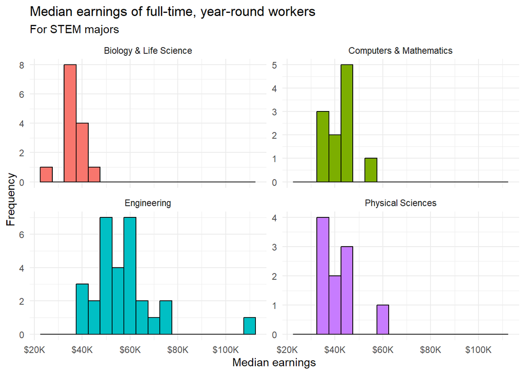

```r
# filter data untuk hanya STEM majors
stem_majors <- college_recent_grads %>%
  filter(major_category %in% c("Biology & Life Science", "Computers & Mathematics", "Engineering", "Physical Sciences"))

# plot histogram
stem_majors %>%
  ggplot(aes(x = median, fill = major_category)) +
  geom_histogram(binwidth = 5000, color = "black") +
  facet_wrap(~major_category, scales = "free_y") +
  scale_x_continuous(labels = dollar_format(prefix="$", scale = 0.001, suffix="K")) +
  labs(title = "Median earnings of full-time, year-round workers",
       subtitle = "For STEM majors",
       x = "Median earnings",
       y = "Frequency") +
  theme_minimal() +
  theme(legend.position = "none")
```

## Exercise 3

Buat ulang visualisasi dari latihan sebelumnya, kali ini dengan lebar bin sebesar $1.000. Mana yang lebih baik antara $1.000 atau $5.000 sebagai pilihan lebar bin? Jelaskan alasan Anda dalam satu kalimat.

**Jawaban:**

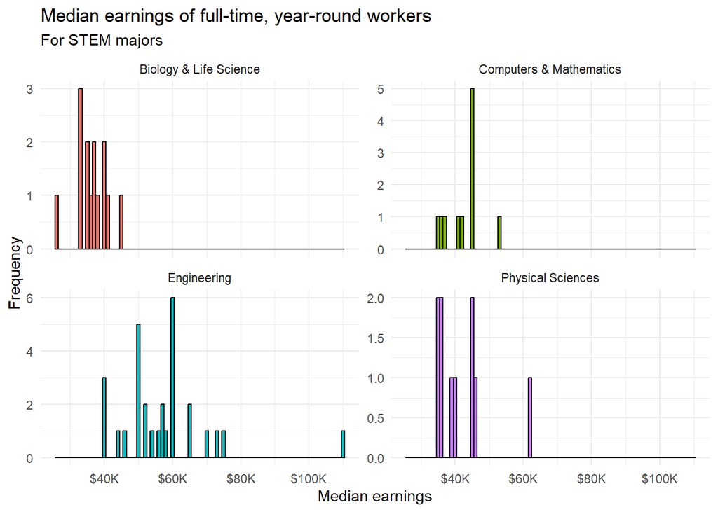

```r
# buat histogram dengan bin width $1,000
ggplot(stem_majors, aes(x = median, fill = major_category)) +
  geom_histogram(binwidth = 1000, color = "black") +
  facet_wrap(~ major_category, scales = "free_y") +
  labs(
    title = "Median earnings of full-time, year-round workers",
    subtitle = "For STEM majors",
    x = "Median earnings",
    y = "Frequency"
  ) +
  scale_x_continuous(labels = scales::dollar_format(prefix="$", scale = 0.001, suffix="K")) +
  theme_minimal() +
  theme(legend.position = "none")
```

Binwidth $1.000 menampilkan lebih banyak batang (bars) dalam histogram, sehingga grafik menjadi lebih rinci tetapi bisa terlihat terlalu berantakan dan sulit diinterpretasikan. Sementara itu, binwidth $5.000 mengelompokkan data ke dalam rentang yang lebih luas, membuat pola distribusi pendapatan lebih jelas dan lebih mudah dibaca, terutama untuk melihat tren utama tanpa terlalu banyak fluktuasi kecil.

## Exercise 4

Jurusan STEM mana (yaitu, jurusan dalam kategori “Biology & Life Science”, “Computers & Mathematics”, “Engineering”, dan “Physical Sciences”) yang memiliki gaji median yang sama dengan atau lebih rendah dari median untuk seluruh jurusan (semua jurusan, bukan hanya yang termasuk dalam kategori STEM)? Output Anda hanya boleh menampilkan nama jurusan serta pendapatan median, persentil ke-25, dan persentil ke-75 untuk jurusan tersebut, dan harus diurutkan sehingga jurusan dengan pendapatan median tertinggi berada di bagian atas.

**Jawaban:**

```r
# median pendapatan untuk semua jurusan
median_all_majors <- median(college_recent_grads$median, na.rm = TRUE)

# memfilter jurusan STEM dengan gaji median ≤ median semua jurusan
stem_below_median <- college_recent_grads %>%
  filter(major_category %in% c("Biology & Life Science", "Computers & Mathematics",
                               "Engineering", "Physical Sciences"),
         median <= median_all_majors) %>%
  select(major, median, p25th, p75th) %>%
  arrange(desc(median))  # Urutan dari yang tertinggi ke terendah

stem_below_median
```

```
## # A tibble: 11 × 4
##    major                                 median p25th p75th
##    <chr>                                  <dbl> <dbl> <dbl>
##  1 Geosciences                            36000 21000 41000
##  2 Environmental Science                  35600 25000 40200
##  3 Multi-Disciplinary Or General Science  35000 24000 50000
##  4 Physiology                             35000 20000 50000
##  5 Communication Technologies             35000 25000 45000
##  6 Neuroscience                           35000 30000 44000
##  7 Atmospheric Sciences And Meteorology   35000 28000 50000
##  8 Miscellaneous Biology                  33500 23000 48000
##  9 Biology                                33400 24000 45000
## 10 Ecology                                33000 23000 42000
## 11 Zoology                                26000 20000 39000
```

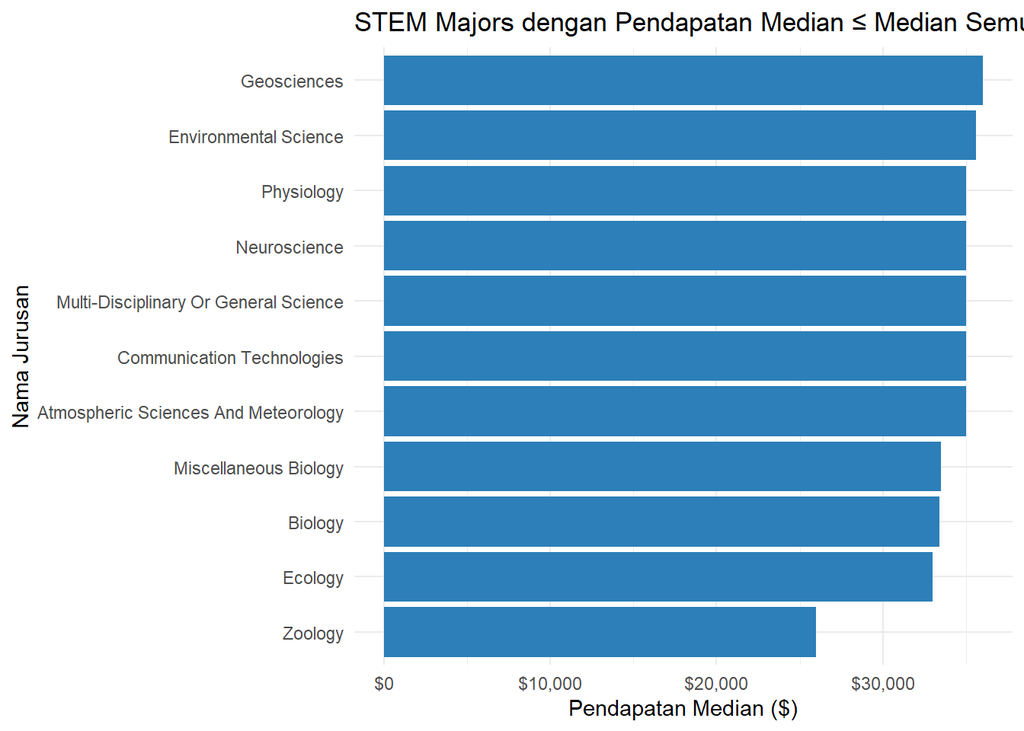

```r
# Visualisasi jurusan STEM dengan median income ≤ median semua jurusan
ggplot(stem_below_median, aes(x = reorder(major, median), y = median)) +
  geom_col(fill = "#2c7fb8") +
  coord_flip() +
  labs(
    title = "STEM Majors dengan Pendapatan Median ≤ Median Semua Jurusan",
    x = "Nama Jurusan",
    y = "Pendapatan Median ($)"
  ) +
  scale_y_continuous(labels = scales::dollar_format()) +
  theme_minimal()
```

## Exercise 5

Buatlah sebuah pertanyaan yang menarik bagi Anda yang dapat dijawab menggunakan setidaknya tiga variabel dari dataset, lalu jawab pertanyaan tersebut menggunakan statistik ringkasan dan/atau visualisasi.

**Pertanyaan**

Bagaimana hubungan antara persentase pengangguran, pendapatan median, dan proporsi perempuan dalam berbagai jurusan di kategori STEM? Apakah jurusan dengan lebih banyak perempuan cenderung memiliki tingkat pengangguran yang lebih tinggi atau pendapatan yang lebih rendah?

**Jawaban**

```r
# memfilter menjadi hanya jurusan STEM
stem_data <- college_recent_grads %>%
  filter(major_category %in% c("Biology & Life Science", "Computers & Mathematics", "Engineering", "Physical Sciences")) %>%
  select(major, major_category, unemployment_rate, median, sharewomen)

summary(stem_data[, c("unemployment_rate", "median", "sharewomen")])
```

```
##  unemployment_rate     median         sharewomen
##  Min.   :0.00000   Min.   : 26000   Min.   :0.07745
##  1st Qu.:0.04704   1st Qu.: 37875   1st Qu.:0.21703
##  Median :0.06092   Median : 45000   Median :0.33336
##  Mean   :0.06377   Mean   : 47861   Mean   :0.36976
##  3rd Qu.:0.08149   3rd Qu.: 56250   3rd Qu.:0.53066
##  Max.   :0.17723   Max.   :110000   Max.   :0.75047
```

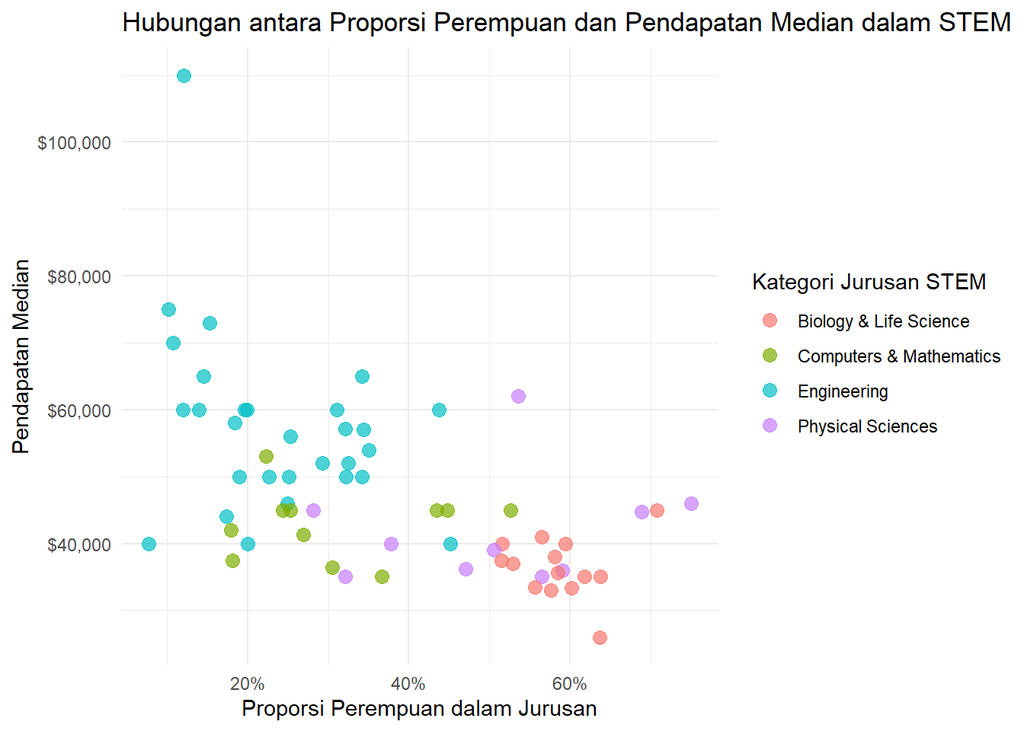

```r
# visualisasi hubungan antara persentase perempuan dan pendapatan median
ggplot(stem_data, aes(x = sharewomen, y = median, color = major_category)) +
  geom_point(size = 3, alpha = 0.7) +
  labs(
    title = "Hubungan antara Proporsi Perempuan dan Pendapatan Median dalam STEM",
    x = "Proporsi Perempuan dalam Jurusan",
    y = "Pendapatan Median",
    color = "Kategori Jurusan STEM"
  ) +
  scale_x_continuous(labels = scales::percent) +
  scale_y_continuous(labels = scales::dollar_format()) +
  theme_minimal()
```

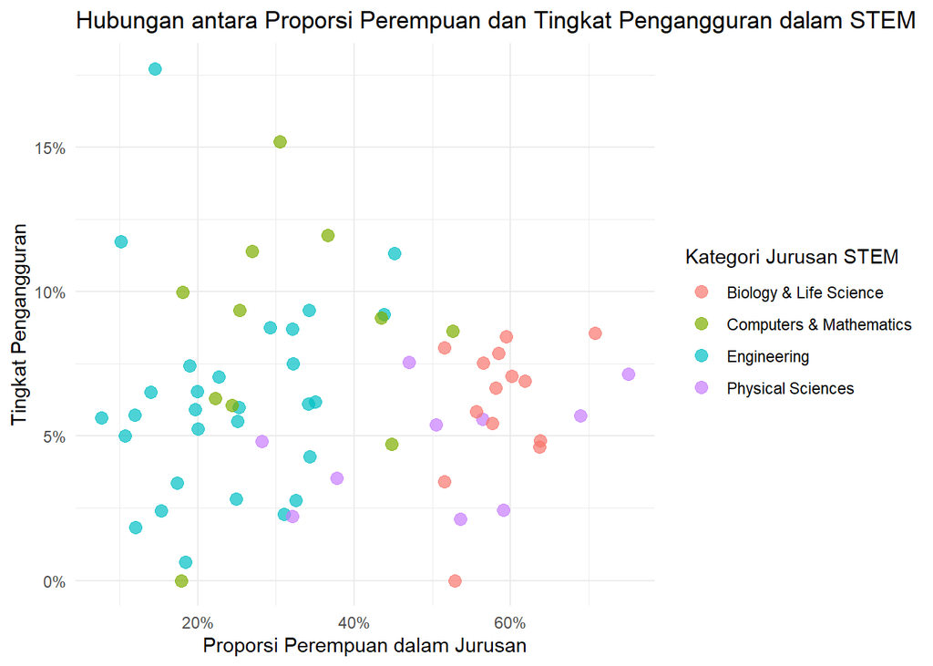

```r
# visualisasi hubungan antara proporsi perempuan dan tingkat pengangguran
ggplot(stem_data, aes(x = sharewomen, y = unemployment_rate, color = major_category)) +
  geom_point(size = 3, alpha = 0.7) +
  labs(
    title = "Hubungan antara Proporsi Perempuan dan Tingkat Pengangguran dalam STEM",
    x = "Proporsi Perempuan dalam Jurusan",
    y = "Tingkat Pengangguran",
    color = "Kategori Jurusan STEM"
  ) +
  scale_x_continuous(labels = scales::percent) +
  scale_y_continuous(labels = scales::percent) +
  theme_minimal()
```